# Making Plots with Julia

## Introduction

There are several ways to make plots in Julia. The two most widely-used graphing ecosystems are:

- [`Plots.jl`](https://docs.juliaplots.org/stable/) — a high-level interface that can target many different rendering **backends**. You write the same `Plots.jl` code regardless of which backend you choose.
- [`Makie.jl`](https://docs.makie.org/stable/) — a modern, GPU-accelerated plotting system that gives you very fine control over every visual element. Its most popular backend for publication-quality vector output is [`CairoMakie.jl`](https://docs.makie.org/stable/explanations/backends/cairomakie).

Other notable libraries include [`VegaLite.jl`](https://github.com/queryverse/VegaLite.jl) (a declarative grammar-of-graphics inspired by ggplot2) and [`Gadfly.jl`](https://gadflyjl.org/stable/).

### `Plots.jl` and Its Backends

`Plots.jl` itself does not draw anything — it hands off the rendering to a backend. Several backends are available: [^1]

<sup>1</sup> This tutorial focuses on GR and PythonPlot; see the [Plots.jl backend gallery](https://docs.juliaplots.org/latest/backends/) for the full list.

- **[GR](https://github.com/jheinen/GR.jl)** — the default backend. Fast, simple, and works out of the box.
- **[PythonPlot](https://github.com/JuliaPy/PythonPlot.jl)** — uses Python’s `matplotlib` via `PythonCall.jl`. If you already know `matplotlib`, this backend may feel the most familiar.
- **[PlotlyJS](https://github.com/JuliaPlots/PlotlyJS.jl)** — interactive, web-based plots using plotly.js.
- **[PGFPlotsX](https://github.com/JuliaTeX/PGFPlotsX.jl)** — high-quality LaTeX/TikZ output for publications.
- **[UnicodePlots](https://github.com/JuliaPlots/UnicodePlots.jl)** — plots directly in the terminal using Unicode characters.

This tutorial will give examples of making plots using `Plots.jl` (with the `GR` backend), and will show how the `PythonPlot` backend and `Makie.jl` produce equivalent results. Relevant documentation resources are listed below.

## Some Resources

### `Plots.jl`

- [Useful tips](https://docs.juliaplots.org/latest/basics/#Useful-Tips)
- [Examples](https://docs.juliaplots.org/latest/generated/gr/)
- [Plot attributes](http://docs.juliaplots.org/latest/generated/attributes_plot/)
- [Axis attributes](http://docs.juliaplots.org/latest/generated/attributes_axis/#Axis)

### `Makie.jl`

- [Documentation](https://docs.makie.org/stable/)
- [Plotting function reference](https://docs.makie.org/stable/reference/plots)
- [Beautiful Makie (gallery)](https://beautiful.makie.org)

### `PythonPlot`

- [GitHub repository](https://github.com/JuliaPy/PythonPlot.jl)

### Color and styling

- [Color names](http://juliagraphics.github.io/Colors.jl/stable/namedcolors/)
- [Colors.jl colormaps and scales](https://juliagraphics.github.io/Colors.jl/stable/colormapsandcolorscales/)

## Setup

Since we’ll be generating random numbers, load the packages and set a seed for reproducibility.

```julia
using Plots
using StatsPlots   # for distribution plots; re-exports Plots
using CairoMakie   # the vector-graphics Makie backend
using LaTeXStrings
using Measures
using Random
Random.seed!(1);
```

**Note`Plots.jl` Backends and Makie**

`Plots.jl` is more of a common interface for several different plotting ecosystems (called **backends**) than a self-contained plotting package. By default, `Plots.jl` uses the `GR` backend, which is pretty basic and fast; I will use this in class for simplicity. You switch backends at any time by calling their name, e.g. `gr()` or `pythonplot()`.

You can and should feel free to use [other backends](https://docs.juliaplots.org/latest/backends/) if you find them more intuitive or useful for the plot(s) you are trying to make. In particular, you might find `PythonPlot` simple to use if you feel comfortable with `matplotlib` in Python. The downside to `PythonPlot` is that it relies on Python to render the plots; if you don’t have Python installed, [`CondaPkg.jl`](https://github.com/JuliaPy/CondaPkg.jl) will install a private copy automatically (which can take a few minutes the first time).

Below, each plot example is shown in a tabset for three approaches: the `GR` backend, the `PythonPlot` backend, and `Makie.jl`.

**TipMakie Function Names in This Tutorial**

Because this document has both `Plots.jl` and `Makie` loaded at once, a few function names that exist in both packages (such as `scatter` and `heatmap`) are written as `Makie.scatter` and `Makie.heatmap` in the Makie tabs. In your own scripts, where you would normally load only one of the two, you can drop the `Makie.` prefix.

## Making a Basic Plot

Let’s walk through making a basic line plot.

First, to generate a basic line plot, use `plot()`:

```julia
x = 1:5
y = rand(length(x))
plot(x, y, label="Original Data", legend=:topleft)
```

**1**

This creates `x` as a range of integers between 1 and 5 (inclusive of both endpoints). You can use arbitrary steps with syntax like `x = 1:0.1:5`. To turn `x` into a vector instead of a range, you can use `collect(x)`, but this is not needed for plotting (Julia does this under the hood).

**2**

`y` is a vector of random values (uniformly distributed between 0 and 1) with the same length as `x`. This type of syntax is better than hard-coding the length into `y`, since you might want to use different lengths.

**3**

[figure not shown]

Here, we explicitly passed in `x` to provide the $x$ coordinates for the plotted values. If only one array is passed[^2], `Plots.jl` will interpret the values as $y$ coordinates and use their indices for the $x$ positions.

<sup>2</sup> This syntax might look like `plot(y, ...)` instead of `plot(x, y, ...)`.

Now add more series and axis labels.

**TipMutating Function**

The exclamation mark says that `plot!()` is a **mutating function**, which changes an existing plot instead of creating a new one. Try removing the `!` — you will get a new plot that no longer contains the old elements.

```julia
y2 = rand(5)
y3 = rand(5)
```

```
5-element Vector{Float64}:
 0.5710874493423871
 0.4528085872833483
 0.30232547191787174
 0.0013502779247226426
 0.5670236732404312
```

**GR (Plots.jl)**

```julia
gr()
plot(x, y, label="Original Data")
plot!(x, y2, color=:red, linewidth=2, linestyle=:dot, label="New Data")
scatter!(x, y3, markercolor=:black, markershape=:square, markersize=5, label="Point Data")
xlabel!("Regular String (days)")
ylabel!(L"LaTeX String $x_2$ (m$^3$)")
```

[figure not shown]

**PythonPlot (Plots.jl)**

```julia
pythonplot()
plot(x, y, label="Original Data")
plot!(x, y2, color=:red, linewidth=2, linestyle=:dot, label="New Data")
scatter!(x, y3, markercolor=:black, markershape=:square, markersize=5, label="Point Data")
xlabel!("Regular String (days)")
ylabel!(L"LaTeX String $x_2$ (m$^3$)")
```

[figure not shown]

**Makie.jl**

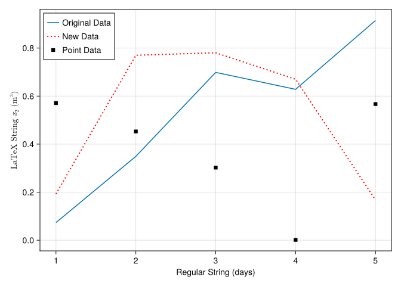

```julia
fig = Figure()
ax = Axis(fig[1, 1], xlabel="Regular String (days)", ylabel=L"LaTeX String $x_2$ (m$^3$)")
lines!(ax, x, y, label="Original Data")
lines!(ax, x, y2, color=:red, linewidth=2, linestyle=:dot, label="New Data")
Makie.scatter!(ax, x, y3, color=:black, marker=:rect, markersize=10, label="Point Data")
axislegend(ax, position=:lt)
fig
```

### Removing Plot Elements

Sometimes we want to remove legends, axes, grid lines, and/or ticks.

```julia
plot!(legend=false, axis=false, grid=false, ticks=false)
```

[figure not shown]

Notice that this unintentionally modified the image dimensions to move the axis labels off the page. If we wanted to keep them, we could modify the dimensions with `plot!(size=...)`.

```julia
plot!(size=(400, 400))
```

[figure not shown]

The lesson is that sometimes the `Plots.jl` defaults don’t look ideal, and we need to adjust sizes and margins. Don’t shy away from these tweaks if they make your figures easier to read or interpret!

### Aspect Ratio

For a square aspect ratio, `Plots.jl` uses `ratio = 1`; `Makie.jl` uses `aspect = AxisAspect(1)`.

```julia
v = rand(5)
```

```
5-element Vector{Float64}:
 0.6159379234562881
 0.19573857852575793
 0.012461945950411835
 0.3119923865097316
 0.11479916823306191
```

**GR (Plots.jl)**

```julia
gr()
plot(v, ratio=1, legend=false)
scatter!(v)
```

[figure not shown]

**PythonPlot (Plots.jl)**

```julia
pythonplot()
plot(v, ratio=1, legend=false)
scatter!(v)
```

[figure not shown]

**Makie.jl**

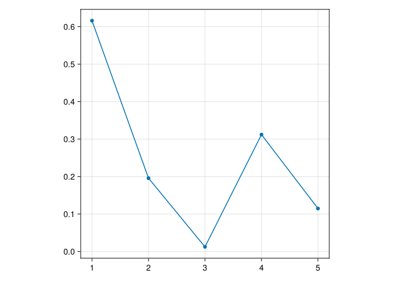

```julia
fig = Figure()
ax = Axis(fig[1, 1], aspect=AxisAspect(1))
lines!(ax, v)
Makie.scatter!(ax, v)
fig
```

## Plot Demos

This section includes some examples of how to make other types of plots.

### Heatmaps

A heatmap is a plotted matrix whose cells are colored by value. Use `clim` (Plots) or `colorrange` (Makie) to fix the color scale.

```julia
A = rand(10, 10)
```

**1**

Create a random 10×10 matrix, but this could come from actual data.

```
10×10 Matrix{Float64}:
 0.742414  0.108674  0.0909513  0.818597   …  0.239896   0.96551   0.229329
 0.65913   0.265374  0.914553   0.859535      0.327377   0.81217   0.575938
 0.360275  0.699443  0.590472   0.375186      0.109344   0.430081  0.243464
 0.892222  0.036808  0.967915   0.947293      0.51529    0.599123  0.342309
 0.337329  0.633275  0.673935   0.373811      0.0913972  0.82805   0.835509
 0.671766  0.295391  0.228969   0.0223076  …  0.585548   0.592562  0.0590473
 0.534097  0.348069  0.46191    0.110385      0.120938   0.982151  0.551654
 0.655354  0.427535  0.577283   0.226571      0.628025   0.439115  0.139791
 0.404693  0.60398   0.139681   0.857178      0.59816    0.938309  0.540769
 0.703556  0.641963  0.129069   0.0568809     0.717561   0.593831  0.775324
```

**GR (Plots.jl)**

```julia
gr()
heatmap(A, clim=(0, 1))
```

[figure not shown]

**PythonPlot (Plots.jl)**

```julia
pythonplot()
heatmap(A, clim=(0, 1))
```

[figure not shown]

**Makie.jl**

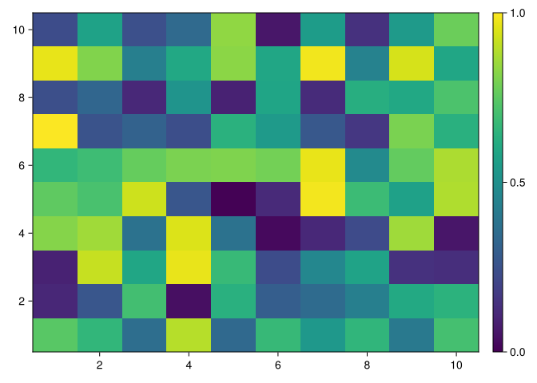

```julia
fig = Figure()
ax = Axis(fig[1, 1])
hm = Makie.heatmap!(ax, A, colorrange=(0, 1))
Colorbar(fig[1, 2], hm)
fig
```

```julia
M = [ 0 1 0; 0 0 0; 1 0 0]
whiteblack = [RGBA(1,1,1,0), RGB(0,0,0)]
heatmap(M, c=whiteblack, aspect_ratio = 1, ticks=.5:3.5, lims=(.5,3.5), gridalpha=1, legend=false, axis=false, ylabel="i", xlabel="j")
```

**1**

This creates a vector of colors, so `0` (the lower value) will map to `whiteblack[1]` (which is white) and `1` will map to `whiteblack[2]` (black). The specific `0` and `1` values don’t matter for this syntax, just that there are two distinct values; the lower one will always be mapped to white. Try changing the values of `M` to `1` and `2`!

[figure not shown]

#### Custom Colormaps

Use a custom set of colors instead of the default gradients.

```julia
using Colors

mycolors = [colorant"lightslateblue",colorant"limegreen",colorant"red"]
A2 = [i for i=50:300, j=1:100]
```

**1**

`Colors.jl` provides [many named colors](https://juliagraphics.github.io/Colors.jl/stable/namedcolors/). The `colorant` function converts a name to an RGB value.

**2**

```
251×100 Matrix{Int64}:
  50   50   50   50   50   50   50   50  …   50   50   50   50   50   50   50
  51   51   51   51   51   51   51   51      51   51   51   51   51   51   51
  52   52   52   52   52   52   52   52      52   52   52   52   52   52   52
  53   53   53   53   53   53   53   53      53   53   53   53   53   53   53
  54   54   54   54   54   54   54   54      54   54   54   54   54   54   54
  55   55   55   55   55   55   55   55  …   55   55   55   55   55   55   55
  56   56   56   56   56   56   56   56      56   56   56   56   56   56   56
  57   57   57   57   57   57   57   57      57   57   57   57   57   57   57
  58   58   58   58   58   58   58   58      58   58   58   58   58   58   58
  59   59   59   59   59   59   59   59      59   59   59   59   59   59   59
   ⋮                        ⋮            ⋱              ⋮
 292  292  292  292  292  292  292  292     292  292  292  292  292  292  292
 293  293  293  293  293  293  293  293     293  293  293  293  293  293  293
 294  294  294  294  294  294  294  294     294  294  294  294  294  294  294
 295  295  295  295  295  295  295  295  …  295  295  295  295  295  295  295
 296  296  296  296  296  296  296  296     296  296  296  296  296  296  296
 297  297  297  297  297  297  297  297     297  297  297  297  297  297  297
 298  298  298  298  298  298  298  298     298  298  298  298  298  298  298
 299  299  299  299  299  299  299  299     299  299  299  299  299  299  299
 300  300  300  300  300  300  300  300  …  300  300  300  300  300  300  300
```

**GR (Plots.jl)**

```julia
gr()
heatmap(A2, c=mycolors, clim=(50, 300))
```

[figure not shown]

**PythonPlot (Plots.jl)**

```julia
pythonplot()
heatmap(A2, c=mycolors, clim=(50, 300))
```

[figure not shown]

**Makie.jl**

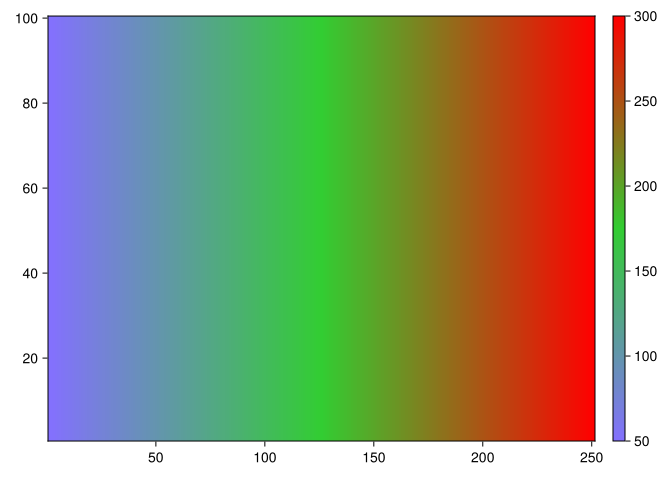

```julia
fig = Figure()
ax = Axis(fig[1, 1])
hm = Makie.heatmap!(ax, A2, colormap=mycolors, colorrange=(50, 300))
Colorbar(fig[1, 2], hm)
fig
```

### Area Under a Curve

`areaplot()` fills the region between a curve and the x-axis. The Makie equivalent is `band!` with a zero lower bound.

```julia
xa = -3:0.01:3
fa = exp.(-xa.^2/2) / √(2π)
```

```
601-element Vector{Float64}:
 0.0044318484119380075
 0.004566589954670145
 0.004704957526933979
 0.004847032905978945
 0.004992899213612376
 0.005142640923053939
 0.00529634386531102
 0.005454095235056545
 0.005615983595990969
 0.005782098885669473
 ⋮
 0.005615983595990969
 0.005454095235056545
 0.00529634386531102
 0.005142640923053939
 0.004992899213612376
 0.004847032905978945
 0.004704957526933979
 0.004566589954670145
 0.0044318484119380075
```

**GR (Plots.jl)**

```julia
gr()
areaplot(xa, fa, alpha=0.25, legend=false)
```

[figure not shown]

**PythonPlot (Plots.jl)**

```julia
pythonplot()
areaplot(xa, fa, alpha=0.25, legend=false)
```

[figure not shown]

**Makie.jl**

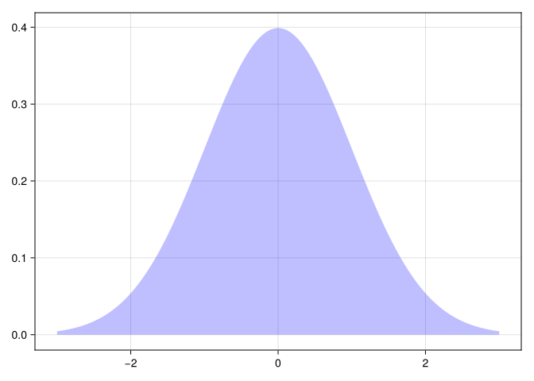

```julia
fig = Figure()
ax = Axis(fig[1, 1])
band!(ax, xa, fill(0.0, length(xa)), fa, color=(:blue, 0.25))
fig
```

#### Stacked Area Plots

```julia
years = ["2021", "2022", "2023"]
# Each row is a source; each column is a year.
# Sources: Solar, Wind, Hydro, Coal (values in GWh)
energy = [
    120  180  260;    # Solar (growing)
    200  220  240;    # Wind
    150  140  130;    # Hydro (declining)
     80   60   40     # Coal (declining)
]
sources = ["Solar", "Wind", "Hydro", "Coal"]

p = areaplot(1:3, energy',               # transpose so each column = layer
    seriescolor = [:orange :skyblue :steelblue :gray],
    fillalpha   = [0.6, 0.5, 0.4, 0.5],
    labels      = reshape(sources, 1, :), # one label per layer
    legend      = :topleft,
    xticks      = (1:3, years),
    xlabel      = "Year",
    ylabel      = "Energy Use (GWh)"
)
```

[figure not shown]

When you pass a matrix, each column becomes its own stacked layer. The `seriescolor` and `fillalpha` vectors control the color and transparency per layer. The `labels` must be a row matrix (`reshape(sources, 1, :)`) to match the matrix orientation. Try experimenting — change the values or colors to see how the plot adjusts.

The `fillrange` option lets us color the area between two arbitrary lines/curves if we only want to treat one of those curves as a boundary. `fillcolor` and `fillalpha` let you change the color and transparency of the filled area.

```julia
y = rand(10)
plot(y, fillrange= y.*0 .+ .5, label= "above/below 1/2", fillcolor=:red, legend =:top)
```

[figure not shown]

#### Confidence Band

Use `fillrange` to color the region between two curves, e.g. to show a confidence band.

```julia
xb = LinRange(0, 2, 100)
y1 = exp.(xb)
y2 = exp.(1.3 .* xb)
```

**1**

`LinRange` creates a range from 0 to 2 with 100 evenly spaced points.

```
100-element Vector{Float64}:
  1.0
  1.0266105279586968
  1.0539291761156344
  1.0819747879231458
  1.1107667082677797
  1.1403247968137291
  1.1706694417013364
  1.2018215736101217
  1.233802680196039
  1.2666348209129108
  ⋮
 10.912391625589951
 11.20277612803896
 11.500887915409168
 11.806932614831997
 12.121121325285433
 12.443670763202702
 12.774803411955727
 13.11474767531643
 13.463738035001692
```

**GR (Plots.jl)**

```julia
gr()
plot(xb, y1, fillrange=y2, fillalpha=0.35, c=1, label="Confidence band", legend=:topleft)
```

[figure not shown]

**PythonPlot (Plots.jl)**

```julia
pythonplot()
plot(xb, y1, fillrange=y2, fillalpha=0.35, c=1, label="Confidence band", legend=:topleft)
```

[figure not shown]

**Makie.jl**

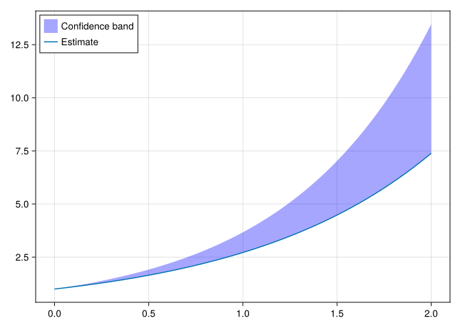

```julia
fig = Figure()
ax = Axis(fig[1, 1])
band!(ax, xb, y1, y2, color=(:blue, 0.35), label="Confidence band")
lines!(ax, xb, y1, label="Estimate")
axislegend(ax, position=:lt)
fig
```

We can also get more creative and color different parts of a curve differently. Here, we divide a normal distribution into 100 quantiles and alternate red and blue stripes. We’ll do this using the `erfinv()` function from `SpecialFunctions.jl` to calculate the quantiles using the inverse cumulative distribution function, but there are other approaches using `Distributions.jl`.

```julia
using SpecialFunctions

# write a function for the normal distribution density
f(x) = exp(-x^2/2)/√(2π)
# get the edges of the quantiles
δ = .01
x = √2 .* erfinv.(2 .* (δ/2 : δ : 1) .- 1)
# make the plot and draw the density line in black
areaplot(x, f.(x), seriescolor=[ :red,:blue], legend=false)
plot!(x, f.(x),c=:black)
```

[figure not shown]

### Plotting Shapes

We can also draw shapes more directly, such as rectangles and circles.

```julia
rectangle(w, h, x, y) = Shape(x .+ [0,w,w,0], y .+ [0,0,h,h])
circle(r,x,y) = (θ = LinRange(0,2π,500); (x.+r.*cos.(θ), y.+r.*sin.(θ)))
plot(circle(5,0,0), ratio=1, c=:red, fill=true)
plot!(rectangle(5*√2,5*√2,-2.5*√2,-2.5*√2),c=:white,fill=true,legend=false)
```

[figure not shown]

### Plotting Distributions

[`StatsPlots.jl`](https://github.com/JuliaPlots/StatsPlots.jl) adds distribution-plotting recipes. `Makie.jl` requires computing the PDF explicitly with `Distributions.jl`.

```julia
using Distributions
d = Normal(2, 5)
xs_dist = range(-15, 20, length=300)
```

```
-15.0:0.11705685618729098:20.0
```

**GR (Plots.jl)**

```julia
gr()
plot(d)
```

[figure not shown]

**PythonPlot (Plots.jl)**

```julia
pythonplot()
plot(d)
```

[figure not shown]

**Makie.jl**

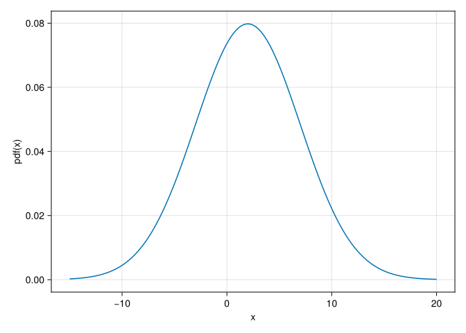

```julia
fig = Figure()
ax = Axis(fig[1, 1], xlabel="x", ylabel="pdf(x)")
lines!(ax, xs_dist, pdf.(d, xs_dist))
fig
```

#### Kernel Density Estimate

```julia
samples = rand(d, 2000)
```

```
2000-element Vector{Float64}:
  1.5245899213514686
  4.24310012818435
  3.4922212945438504
  4.857580339253022
 -1.0847650373991686
  0.34742627716202557
 -3.8740430084774573
  0.6981636365869883
 -1.7086625454229645
  0.5531704345757209
  ⋮
  2.519087067670294
  0.2482312995844831
  9.895844005945166
  6.946334488918343
  9.527402479478546
  3.6776118640373947
  9.825093587382582
  3.1282935080762977
 -1.4111479173941746
```

**GR (Plots.jl)**

```julia
gr()
density(samples, label="KDE", legend=:topleft)
```

[figure not shown]

**PythonPlot (Plots.jl)**

```julia
pythonplot()
density(samples, label="KDE", legend=:topleft)
```

[figure not shown]

**Makie.jl**

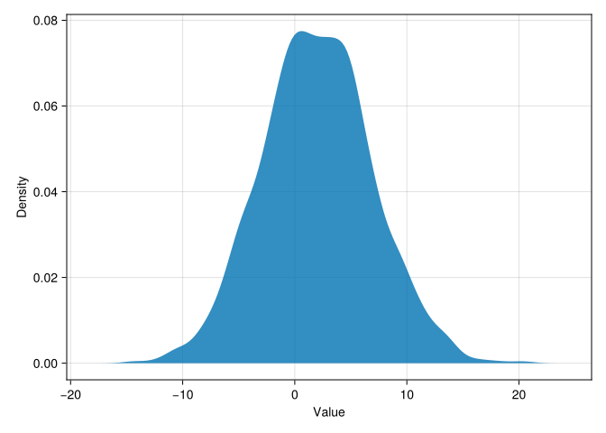

```julia
fig = Figure()
ax = Axis(fig[1, 1], xlabel="Value", ylabel="Density")
Makie.density!(ax, samples)
fig
```

#### DataFrame Density

`StatsPlots.jl` also integrates with `DataFrames.jl`:

```julia
using DataFrames
dat = DataFrame(a = 1:10, b = 10 .+ rand(10), c = 10 .* rand(10))
@df dat density([:b :c], color=[:black :red])
```

**1**

`@df` is an example of a **macro**, which modifies the subsequent function. There are many other examples of macros in Julia.

[figure not shown]

### Log-Scaled Axes

```julia
xx = 0.1:0.1:10
```

```
0.1:0.1:10.0
```

**GR (Plots.jl)**

```julia
gr()
plot(xx, xx.^2, xaxis=:log, yaxis=:log, legend=false)
```

[figure not shown]

**PythonPlot (Plots.jl)**

```julia
pythonplot()
plot(xx, xx.^2, xaxis=:log, yaxis=:log, legend=false)
```

[figure not shown]

**Makie.jl**

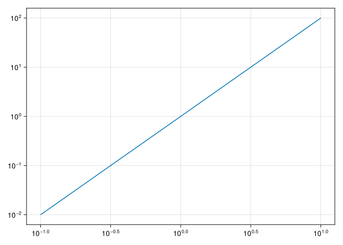

```julia
fig = Figure()
ax = Axis(fig[1, 1], xscale=log10, yscale=log10)
lines!(ax, xx, xx .^ 2)
fig
```

```julia
plot(exp.(x), yaxis=:log)
```

[figure not shown]

## Editing Plots Manually

Now let’s look at how to modify plot attributes directly.

```julia
pl = plot(1:4,[1, 4, 9, 16])
```

[figure not shown]

To get a list of properties we can modify, use `p.attr`:

```julia
pl.attr
```

```
RecipesPipeline.DefaultsDict with 30 entries:
  :dpi                      => 96
  :background_color_outside => :match
  :plot_titlefontvalign     => :vcenter
  :warn_on_unsupported      => true
  :background_color         => RGBA{Float64}(1.0, 1.0, 1.0, 1.0)
  :inset_subplots           => nothing
  :size                     => (672, 480)
  :display_type             => :auto
  :overwrite_figure         => true
  :html_output_format       => :auto
  :plot_titlefontfamily     => :match
  :plot_titleindex          => 0
  :foreground_color         => RGB{N0f8}(0.0, 0.0, 0.0)
  :window_title             => "Plots.jl"
  :plot_titlefontrotation   => 0.0
  :extra_plot_kwargs        => Dict{Any, Any}()
  :pos                      => (0, 0)
  :plot_titlefonthalign     => :hcenter
  :tex_output_standalone    => false
  ⋮                         => ⋮
```

We can also directly access properties of the plotted series.

```julia
pl.series_list[1]
```

```
Plots.Series(RecipesPipeline.DefaultsDict(:plot_object => Plot{Plots.PythonPlotBackend() n=1}, :subplot => Subplot{1}, :label => "y1", :serieshandle => Any[<py [<matplotlib.lines.Line2D object at 0x33c625290>]>], :fillalpha => nothing, :linealpha => nothing, :linecolor => RGBA{Float64}(0.0, 0.605603…
```

```julia
pl[:size]=(300,200)
```

**1**

This is a little contrived: we could just use `plot!(pl, size=(300, 200))` to do the same thing.

```
(300, 200)
```

```julia
pl
```

[figure not shown]

## Saving Plots

To save plots to a file for inclusion in a report writeup:

```julia
save("figure.png", p)
```